# Random forests & bagging

Stat 253

Author

**NOTE:** You should be able to render this document right away, but there will be ERROR messages in many of the code chunks until you complete them.

# Small Group Discussion

> **READING**

> For more on this topic, you’re encouraged to read [ISLR](https://www.statlearning.com/) Chapter 8.2.

Within the broader machine learning landscape, we left off by discussing **supervised classification techniques**:

- **build a model** of *categorical variable* y by predictors x
  - parametric model: logistic regression
  - nonparametric models: KNN & trees
- **evaluate the model**  
  We can use CV & in-sample techniques to estimate the accuracy of our classification models.
  - for binary y: sensitivity, specificity, ROC curves
  - for y with any number of categories: overall accuracy rates, category specific accuracy rates

**GOAL**

Add more nonparametric algorithms to our toolkit: **random forests** & **bagging**

## EXAMPLE 1: Anticipation

What does the word “forest” mean to you?

## EXAMPLE 2: Candy!!!

[fivethirtyeight article](https://fivethirtyeight.com/videos/the-ultimate-halloween-candy-power-ranking/)

[the experiment](http://walthickey.com/2017/10/18/whats-the-best-halloween-candy/)

```r
library(tidyverse)
library(tidymodels)
library(rpart)        # for building trees
library(rpart.plot)   # for plotting trees
library(randomForest) # for bagging & forests
library(infer)        # for resampling

library(fivethirtyeight)
data("candy_rankings")

head(candy_rankings)
## # A tibble: 6 × 13
##   competitorname chocolate fruity caramel peanutyalmondy nougat crispedricewafer
##   <chr>          <lgl>     <lgl>  <lgl>   <lgl>          <lgl>  <lgl>
## 1 100 Grand      TRUE      FALSE  TRUE    FALSE          FALSE  TRUE
## 2 3 Musketeers   TRUE      FALSE  FALSE   FALSE          TRUE   FALSE
## 3 One dime       FALSE     FALSE  FALSE   FALSE          FALSE  FALSE
## 4 One quarter    FALSE     FALSE  FALSE   FALSE          FALSE  FALSE
## 5 Air Heads      FALSE     TRUE   FALSE   FALSE          FALSE  FALSE
## 6 Almond Joy     TRUE      FALSE  FALSE   TRUE           FALSE  FALSE
## # ℹ 6 more variables: hard <lgl>, bar <lgl>, pluribus <lgl>,
## #   sugarpercent <dbl>, pricepercent <dbl>, winpercent <dbl>
```

```r
# What are the 6 most popular candies?


# The least popular?
```

## EXAMPLE 3: Build an unpruned tree

*For demonstration purposes only* let’s:

- define a `popularity` variable that categorizes the candies as “low”, “medium”, or “high” popularity
- delete the original `winpercent` variable
- rename variables to make them easier to read in a tree
- make the candy name a row label, not a predictor

```r
candy <- candy_rankings %>%
  mutate(popularity = cut(winpercent, breaks = c(0, 40, 60, 100), labels = c("low", "med", "high"))) %>%
  select(-winpercent) %>%
  rename("price" = pricepercent, "sugar" = sugarpercent, "nutty" = peanutyalmondy, "wafer" = crispedricewafer) %>%
  column_to_rownames("competitorname")
```

Our goal is to model candy `popularity` by all possible predictors in our data.

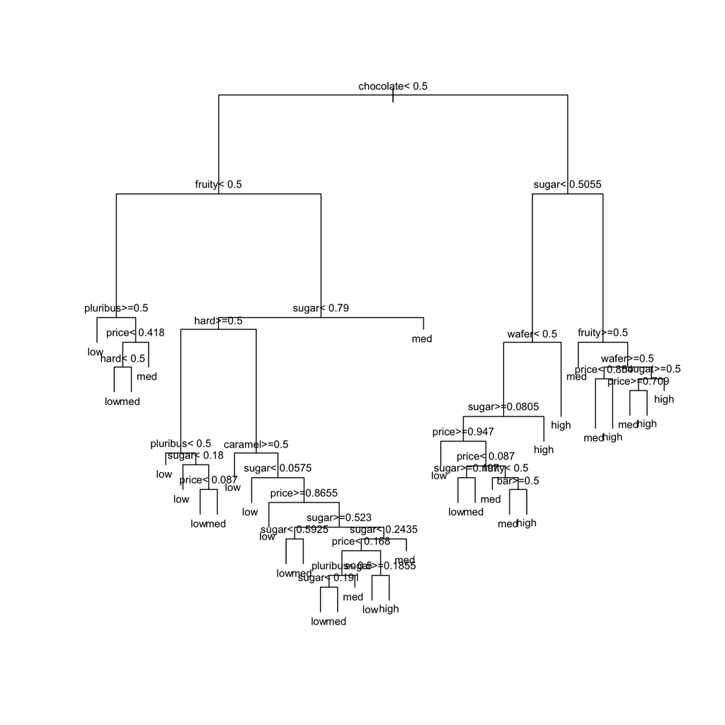

```r
# STEP 1: tree specification
tree_spec <- decision_tree() %>%
  set_mode("classification") %>%
  set_engine(engine = "rpart") %>%
  set_args(cost_complexity = 0, min_n = 2, tree_depth = 30)

# STEP 2: Build the tree! No tuning (hence no workflows) necessary.
original_tree <- tree_spec %>%
  fit(popularity ~ ., data = candy)

# Plot the tree
original_tree %>%
  extract_fit_engine() %>%
  plot(margin = 0)
original_tree %>%
  extract_fit_engine() %>%
  text(cex = 0.7)
```

Ideally, our classification algorithm would have both low bias and low variance:

- low variance = the results wouldn’t change much if we changed up the data set
- low bias = within any data set, the predictions of y tend to have low error / high accuracy

Unfortunately, like other **overfit** algorithms, unpruned trees don’t enjoy both of these. They have…

- low bias, low variance
- low bias, high variance
- high bias, low variance
- high bias, high variance